# GED-16 — código da análise final

Este caderno contém os códigos em R e reproduz o modelo usado na apresentação final. O artigo em LaTeX permanece numa etapa posterior. O relatório antigo em `relatorio/` não corresponde a este ajuste.

## Pergunta, dados e escopo

Quais características socioeconômicas, demográficas e geográficas estão associadas à taxa de homicídios nos municípios brasileiros?

A resposta é a média anual de óbitos por residência em 2021–2023, por cem mil habitantes, usando a população de 2022. A medida soma agressões (X85–Y09) e intervenções legais/operações de guerra (Y35–Y36). Ela se relaciona à ODS 16 e difere da definição internacional do indicador 16.1.1.

Os dados vêm do SIM/DATASUS, do Censo 2022 do IBGE e dos indicadores educacionais de 2022 do INEP. O município é a unidade de observação. Região é uma variável explicativa, com o Sudeste como referência. O ajuste usa municípios com pelo menos 30 mil habitantes, sem Campos do Jordão-SP por suspeita documentada de sub-registro. O Gini é uma aproximação pelas classes de renda das pessoas de quatorze anos ou mais. A migração mede residência ininterrupta inferior a dez anos, sem restringir a origem internacional.

## Reprodução

Mantenha este `.qmd` junto à pasta `dados/`, que contém as bases e a malha municipal. Execute `quarto render analise_final.qmd` nesta pasta, com R e os pacotes usados nos códigos abaixo instalados. A execução recria as tabelas e figuras em `resultados/` e gera um HTML com os códigos e a interpretação. Cada parte executa em ambiente separado. Os códigos comentados abaixo reproduzem os dois scripts da entrega.

## Código completo: análise exploratória

**Código**

```r
exploratoria <- local({
  # =============================================================================
  # Fatores associados aos homicídios nos municípios brasileiros
  # Parte 1 - Análise exploratória
  #
  # Entrada: dados/base_analitica.csv e dados/variaveis_extras.csv (1 linha por município) e dados/malha_mun.geojson
  # Saída:   resultados/eda/ (figuras e tabelas)
  # Rodar com a pasta entrega/ como diretório de trabalho.
  #
  # Escopo: a análise é feita nos municípios com 30 mil habitantes ou mais, o percentil 80 da população
  # (o mesmo do modelo). Só a definição do escopo e o mapa usam todos os 5.570 municípios.
  # =============================================================================

  rm(list = ls())

  library(ggplot2)
  library(dplyr)
  library(tidyr)
  library(GGally)
  library(sf)

  set.seed(16)
  dir.create("resultados/eda", recursive = TRUE, showWarnings = FALSE)

  # -----------------------------------------------------------------------------
  # Leitura
  # -----------------------------------------------------------------------------
  br <- read.csv("dados/base_analitica.csv")
  br <- merge(br, read.csv("dados/variaveis_extras.csv"), by = "cod_ibge")    # educação (INEP) e migração
  str(br)

  taxa_br <- sum(br$hom) / sum(br$exposure) * 1e5    # taxa nacional (todos os municípios)

  # Escopo: municípios com 30 mil habitantes ou mais. Nesse porte, a taxa nacional dá pelo menos 20 homicídios
  # esperados em 3 anos (casos_esperados_corte)
  POP_MIN <- 30000
  # Campos do Jordão-SP fica fora: 1 homicídio registrado e 36 óbitos de intenção indeterminada (indício de sub-registro)
  FORA <- 3509700
  br$escopo <- br$pop >= POP_MIN & br$cod_ibge != FORA
  casos_esperados_corte <- POP_MIN * 3 * taxa_br / 1e5

  # Percentil da população de cada município (0 a 100): mostra onde o corte fica entre os 5.570 municípios
  percentil <- function(x) 100 * (rank(x) - 0.5) / length(x)
  br$p_pop <- percentil(br$pop)
  percentil_corte <- 100 * mean(br$pop < POP_MIN)

  # Percentil de cada município e resumo do corte por região
  perc <- br[, c("cod_ibge", "municipio", "uf", "regiao", "pop", "p_pop")]
  perc$considerado <- ifelse(br$escopo, "sim", "não")
  perc$regiao <- factor(perc$regiao, levels = c("N", "NE", "CO", "SE", "S"),
                        labels = c("Norte", "Nordeste", "Centro-Oeste", "Sudeste", "Sul"))
  perc <- perc[order(-perc$pop), ]
  write.csv(perc, "resultados/eda/percentis_municipios.csv", row.names = FALSE)
  corte_regiao <- perc %>% group_by(regiao) %>%
    summarise(municipios = n(), considerados = sum(considerado == "sim"),
              pct_pop = 100 * sum(pop[considerado == "sim"]) / sum(pop), .groups = "drop")
  write.csv(corte_regiao, "resultados/eda/corte_regiao.csv", row.names = FALSE)

  # Paleta igual à dos slides: azul do ODS 16, vermelho de destaque e azul-claro de preenchimento
  AZUL <- "#00689D"; VERMELHO <- "#C8343B"; CINZA <- "#7A869A"; FUNDO <- "#FFFFFF"; CLARO <- "#D6E6F2"; MARINHO <- "#13294B"
  th <- theme_minimal(base_size = 12) +
    theme(plot.background = element_rect(fill = FUNDO, colour = NA), panel.grid.minor = element_blank())
  milhar <- function(x) format(x, big.mark = ".", decimal.mark = ",", scientific = FALSE, trim = TRUE)
  assimetria <- function(x) mean((x - mean(x))^3) / sd(x)^3

  # -----------------------------------------------------------------------------
  # 1. Definição do escopo: confiabilidade da taxa por porte do município (todos os municípios)
  #    oscilacao = 1 / raiz(nº esperado de homicídios em 3 anos): variação só pelo acaso
  #    cor_2024  = correlação entre a taxa de 2021-23 e a de 2024 (estabilidade)
  # -----------------------------------------------------------------------------
  br$porte <- cut(br$pop, c(0, 5e3, 1e4, 2e4, 3e4, 5e4, 1e5, Inf), right = FALSE,
                  labels = c("< 5 mil", "5–10 mil", "10–20 mil", "20–30 mil", "30–50 mil", "50–100 mil", ">= 100 mil"))
  porte <- br %>% group_by(porte) %>%
    summarise(municipios = n(), pct_pop = 100 * sum(pop) / sum(br$pop), hom_mediana_3anos = median(hom),
              pct_zero = 100 * mean(hom == 0), oscilacao = 100 / sqrt(median(exposure) * taxa_br / 1e5),
              cor_2024 = cor(taxa, taxa_24), .groups = "drop")
  write.csv(porte, "resultados/eda/confiabilidade_porte.csv", row.names = FALSE)

  # Taxa x população: municípios pequenos têm taxas muito mais dispersas
  p <- ggplot(br, aes(pop, taxa)) + geom_point(size = .4, alpha = .25, colour = AZUL) +
    geom_vline(xintercept = POP_MIN, colour = VERMELHO, linetype = 2) +
    scale_x_log10(labels = milhar) + coord_cartesian(ylim = c(0, 150)) +
    labs(x = "População (escala log)", y = "Taxa de homicídios (/100 mil)") + th
  ggsave("resultados/eda/e0_taxa_pop.png", p, width = 4.8, height = 3.0, dpi = 250)

  # -----------------------------------------------------------------------------
  # 2. Mapa: municípios do escopo coloridos pela taxa; os demais em cinza
  # -----------------------------------------------------------------------------
  g <- st_read("dados/malha_mun.geojson", quiet = TRUE)
  g$cod_ibge <- as.integer(g$codarea)
  gd <- inner_join(g, br, by = "cod_ibge")
  gd$classe <- cut(gd$taxa, c(-Inf, 10, 20, 30, 45, 60, Inf), labels = c("até 10", "10–20", "20–30", "30–45", "45–60", "60+"))
  gd$classe <- factor(ifelse(gd$escopo, as.character(gd$classe), "fora do escopo"),
                      levels = c(levels(gd$classe), "fora do escopo"))
  uf <- gd %>% mutate(uf = substr(cod_ibge, 1, 2)) %>% group_by(uf) %>% summarise()
  p <- ggplot(gd) +
    geom_sf(aes(fill = classe), colour = NA) +
    geom_sf(data = uf, fill = NA, colour = "white", linewidth = .25) +
    scale_fill_manual(values = c("#D6E6F2", "#9EC3DB", "#5E9CC2", AZUL, "#1F4A7A", MARINHO, "#E9EBEE"),
                      name = "Homicídios\npor 100 mil/ano") +
    theme_void(base_size = 10) +
    theme(plot.background = element_rect(fill = FUNDO, colour = NA), legend.position = c(.15, .25))
  ggsave("resultados/eda/e2_mapa_taxa.png", p, width = 4.2, height = 4.2, dpi = 250)
```

```r
  # -----------------------------------------------------------------------------
  # A partir daqui: só os municípios do escopo
  # -----------------------------------------------------------------------------
  d <- br[br$escopo, ]
  d$regiao <- factor(d$regiao, levels = c("N", "NE", "CO", "SE", "S"),
                     labels = c("Norte", "Nordeste", "Centro-Oeste", "Sudeste", "Sul"))
  d$ln_taxa <- log(d$taxa)

  summary(d[, c("taxa", "rend_pc_media", "gini", "pct_pobres", "desocup", "alfabet", "pct_urbana",
                "pct_h1529", "regiao", "amazonia_legal", "faixa_fronteira")])

  rot <- c(taxa = "Taxa de homicídios (/100 mil)", rend_pc_media = "Renda per capita (R$)",
           gini = "Desigualdade (índice de Gini)", pct_pobres = "% pobres (14+)",
           desocup = "Desocupação (%)", alfabet = "Alfabetização (%)", pct_urbana = "% urbana",
           pct_h1529 = "% homens 15–29", freq_15a17 = "Frequência escolar 15–17 (%)",
           abandono_em = "Abandono no ensino médio (%)", distorcao_em = "Distorção idade-série EM (%)",
           pct_migr_10anos = "Migração recente (%)", pop = "População")

  # -----------------------------------------------------------------------------
  # 3. Tabelas-resumo: numéricas (média, quartis, assimetria) e categóricas (frequências)
  # -----------------------------------------------------------------------------
  desc <- d %>% select(all_of(names(rot))) %>%
    pivot_longer(everything()) %>% group_by(name) %>%
    summarise(media = mean(value), dp = sd(value), min = min(value), q1 = quantile(value, .25),
              mediana = median(value), q3 = quantile(value, .75), max = max(value),
              assimetria = assimetria(value), .groups = "drop") %>%
    mutate(var = rot[name]) %>% arrange(match(name, names(rot)))
  write.csv(desc, "resultados/eda/descritiva.csv", row.names = FALSE)

  freq <- bind_rows(
    d %>% count(nivel = regiao) %>% mutate(variavel = "Região"),
    d %>% count(nivel = as.character(amazonia_legal)) %>% mutate(variavel = "Amazônia Legal (1 = sim)"),
    d %>% count(nivel = as.character(faixa_fronteira)) %>% mutate(variavel = "Faixa de fronteira (1 = sim)")) %>%
    mutate(pct = 100 * n / nrow(d)) %>% select(variavel, nivel, n, pct)
  write.csv(freq, "resultados/eda/frequencias.csv", row.names = FALSE)

  # -----------------------------------------------------------------------------
  # E1. Distribuição da resposta: histograma da taxa (avalia a assimetria)
  # -----------------------------------------------------------------------------
  p <- ggplot(d, aes(taxa)) +
    geom_histogram(bins = 40, fill = AZUL, colour = FUNDO, linewidth = .2) +
    labs(x = "Taxa de homicídios (por 100 mil hab./ano)", y = "Nº de municípios") + th
  ggsave("resultados/eda/e1_hist_resposta.png", p, width = 4.8, height = 3.0, dpi = 250)

  # -----------------------------------------------------------------------------
  # E3. Boxplots de ln(taxa) por região
  # -----------------------------------------------------------------------------
  p <- ggplot(d, aes(regiao, ln_taxa)) +
    geom_boxplot(fill = CLARO, colour = AZUL, outlier.size = .4, outlier.alpha = .3, width = .6) +
    stat_summary(fun = mean, geom = "point", colour = VERMELHO, size = 1.6) +
    labs(x = NULL, y = "ln Taxa de homicídios") + th
  ggsave("resultados/eda/e3_box_regiao.png", p, width = 4.8, height = 2.7, dpi = 220)

  # -----------------------------------------------------------------------------
  # E4. Histogramas das explicativas numéricas (assimetria e bimodalidade)
  # -----------------------------------------------------------------------------
  xs <- c("rend_pc_media", "gini", "pct_pobres", "desocup", "alfabet",
          "pct_urbana", "pct_h1529",
          "freq_15a17", "abandono_em", "distorcao_em", "pct_migr_10anos")
  e4 <- d %>% select(all_of(xs)) %>% pivot_longer(everything()) %>%
    mutate(var = factor(rot[name], levels = rot[xs]))
  p <- ggplot(e4, aes(value)) +
    geom_histogram(bins = 40, fill = AZUL, colour = FUNDO, linewidth = .15) +
    facet_wrap(~var, scales = "free", ncol = 5) + labs(x = NULL, y = NULL) + th +
    theme(axis.text = element_text(size = 6.5), strip.text = element_text(size = 7.5))
  ggsave("resultados/eda/e4_hist_explicativas.png", p, width = 7, height = 3.2, dpi = 220)

  # -----------------------------------------------------------------------------
  # E5. Correlações: de cada explicativa com ln(taxa), e entre as explicativas (matriz completa em CSV)
  # -----------------------------------------------------------------------------
  cv <- c(log_rend = "ln Renda", gini = "Desigualdade", pct_pobres = "% pobres", desocup = "Desocupação",
          alfabet = "Alfabetização", pct_urbana = "% urbana",
          pct_h1529 = "% homens 15–29",
          freq_15a17 = "Freq. escolar 15–17", abandono_em = "Abandono EM", distorcao_em = "Distorção EM", pct_migr_10anos = "Migração recente")
  R <- cor(d[, c("ln_taxa", names(cv))])
  dimnames(R) <- list(c("ln Taxa", cv), c("ln Taxa", cv))
  write.csv(round(R, 3), "resultados/eda/correlacao.csv")

  trio <- c("ln Renda", "% pobres", "Alfabetização")         # medem quase o mesmo (multicolinearidade)
  e5 <- data.frame(var = cv, r = R["ln Taxa", cv])
  e5$grupo <- ifelse(e5$var %in% trio, "renda, pobreza e alfabetização", "demais")
  e5$var <- factor(e5$var, levels = e5$var[order(e5$r)])
  p <- ggplot(e5, aes(r, var, fill = grupo)) + geom_col(width = .7) +
    geom_vline(xintercept = 0, colour = CINZA) +
    geom_text(aes(label = sub(".", ",", sprintf("%.2f", r), fixed = TRUE), hjust = ifelse(r > 0, -0.15, 1.15)), size = 3.3) +
    scale_fill_manual(values = c(`renda, pobreza e alfabetização` = VERMELHO, demais = AZUL), name = NULL) +
    scale_x_continuous(limits = c(-.6, .6)) +
    labs(x = "Correlação com ln(taxa)", y = NULL) + th + theme(legend.position = "bottom")
  ggsave("resultados/eda/e5_correlacao.png", p, width = 4.8, height = 4.0, dpi = 250)

  # -----------------------------------------------------------------------------
  # E6. Dispersão: ln(taxa) x cada explicativa, com reta de mínimos quadrados
  # -----------------------------------------------------------------------------
  xs6 <- c(log_rend = "ln Renda per capita", gini = "Desigualdade (índice de Gini)", desocup = "Desocupação (%)",
           pct_urbana = "% urbana",
           pct_h1529 = "% homens 15–29")
  e6 <- d %>% select(ln_taxa, all_of(names(xs6))) %>% pivot_longer(-ln_taxa) %>%
    mutate(var = factor(xs6[name], levels = xs6))
  p <- ggplot(e6, aes(value, ln_taxa)) +
    geom_point(size = .3, alpha = .2, colour = AZUL) +
    geom_smooth(method = "lm", se = FALSE, colour = VERMELHO, linewidth = .7, formula = y ~ x) +
    facet_wrap(~var, scales = "free_x", ncol = 4) + labs(x = NULL, y = "ln Taxa de homicídios") + th +
    theme(strip.text = element_text(size = 7.5), axis.text = element_text(size = 6.5))
  ggsave("resultados/eda/e6_dispersao.png", p, width = 7, height = 3.6, dpi = 220)
```

```r
  # -----------------------------------------------------------------------------
  # E7. Boxplots de ln(taxa) por décimo de renda: mostra a forma (não linear) da relação
  # -----------------------------------------------------------------------------
  d$faixa_renda <- cut(d$rend_pc_media, quantile(d$rend_pc_media, seq(0, 1, .1)),
                       include.lowest = TRUE, dig.lab = 5)
  med_faixa <- d %>% group_by(faixa_renda) %>% summarise(renda = median(rend_pc_media), med = median(ln_taxa))
  p <- ggplot(d, aes(faixa_renda, ln_taxa)) +
    geom_boxplot(fill = CLARO, colour = AZUL, outlier.size = .3, outlier.alpha = .3, width = .6) +
    stat_summary(fun = mean, geom = "point", colour = VERMELHO, size = 1.6) +
    scale_x_discrete(labels = milhar(round(med_faixa$renda))) +
    labs(x = "Renda per capita (R$, mediana de cada décimo)", y = "ln Taxa de homicídios") + th +
    theme(axis.text.x = element_text(angle = 45, hjust = 1))
  ggsave("resultados/eda/e7_box_renda.png", p, width = 4.8, height = 3.2, dpi = 250)

  # -----------------------------------------------------------------------------
  # E8. Matriz de gráficos de dispersão de um subconjunto de variáveis
  # -----------------------------------------------------------------------------
  sub <- d %>% transmute(`ln Taxa` = ln_taxa, `ln Renda` = log_rend, `% pobres` = pct_pobres,
                         `Alfabetização` = alfabet, `% urbana` = pct_urbana)
  p <- ggpairs(sub, lower = list(continuous = wrap("points", size = .25, alpha = .25, colour = AZUL)),
               diag = list(continuous = wrap("densityDiag", fill = CLARO, colour = AZUL))) + th +
    theme(axis.text = element_text(size = 6.5), strip.text = element_text(size = 10))
  ggsave("resultados/eda/e8_pares.png", p, width = 5.4, height = 4.6, dpi = 220)

  # -----------------------------------------------------------------------------
  # Resumo no console
  # -----------------------------------------------------------------------------
  cat("\nConfiabilidade da taxa por porte (todos os municípios):\n"); print(as.data.frame(porte), digits = 3, row.names = FALSE)
  cat(sprintf("\nEscopo: %d municípios (%.1f%% da população) | média da taxa %.1f | mediana %.1f\n",
              nrow(d), 100 * sum(d$pop) / sum(br$pop), mean(d$taxa), median(d$taxa)))
  cat("\nCorrelação de cada explicativa com ln(taxa):\n"); print(round(sort(R["ln Taxa", cv]), 2))
  list(d = d, br = br)
})
```

```
'data.frame':   5570 obs. of  36 variables:
 $ cod_ibge              : int  1100015 1100023 1100031 1100049 1100056 1100064 1100072 1100080 1100098 1100106 ...
 $ cod6                  : int  110001 110002 110003 110004 110005 110006 110007 110008 110009 110010 ...
 $ municipio             : chr  "Alta Floresta D'Oeste" "Ariquemes" "Cabixi" "Cacoal" ...
 $ uf                    : chr  "RO" "RO" "RO" "RO" ...
 $ regiao                : chr  "N" "N" "N" "N" ...
 $ pop                   : int  21494 96833 5351 86887 15890 15663 7519 12627 29414 39387 ...
 $ area_km2              : num  7067 4427 1314 3793 2783 ...
 $ dens                  : num  3.04 21.88 4.07 22.91 5.71 ...
 $ rend_pc_media         : num  1211 1459 1324 1626 1554 ...
 $ pct_pobres            : num  8.87 6.54 4.19 7.88 6.04 ...
 $ gini                  : num  0.429 0.449 0.407 0.478 0.447 ...
 $ desocup               : num  1.69 2.86 1.63 2.12 1.44 ...
 $ alfabet               : num  91.6 94.1 89.8 93.7 92.2 ...
 $ pct_urbana            : num  60.3 86.7 53.2 82.8 88.8 ...
```

[output cut: 22 more lines]

```
Confiabilidade da taxa por porte (todos os municípios):
      porte municipios pct_pop hom_mediana_3anos pct_zero oscilacao cor_2024
    < 5 mil       1324    2.19                 1    36.86     66.21    0.255
   5–10 mil       1170    4.10                 3    11.03     45.90    0.361
  10–20 mil       1366    9.47                 7     2.78     32.65    0.595
  20–30 mil        576    6.91                15     0.00     24.67    0.704
  30–50 mil        477    8.83                23     0.00     19.94    0.756
 50–100 mil        338   11.56                43     0.00     14.79    0.779
 >= 100 mil        319   56.94               121     0.00      8.85    0.887

Escopo: 1133 municípios (77.3% da população) | média da taxa 24.7 | mediana 20.4

Correlação de cada explicativa com ln(taxa):
           ln Renda       Alfabetização            % urbana Freq. escolar 15–17
              -0.48               -0.43               -0.23               -0.16
   Migração recente        Desigualdade         Abandono EM         Desocupação
              -0.04                0.26                0.27                0.30
     % homens 15–29            % pobres        Distorção EM
               0.35                0.40                0.49
```

## Código completo: ajuste e diagnóstico

O modelo principal usa região. O ajuste com estados é somente uma comparação complementar. Os blocos e testes parciais documentam a construção; seus resultados dependem da ordem dos acréscimos.

**Código**

```r
modelo <- local({
  # =============================================================================
  # Fatores associados aos homicídios nos municípios brasileiros
  # Parte 2 - Ajuste do modelo de regressão linear múltipla
  #
  # Entrada: dados/base_analitica.csv e dados/variaveis_extras.csv
  #          (municípios com 30 mil hab. ou mais)
  # Saída:   resultados/modelagem/ (figuras, tabelas e valores_modelo.txt)
  # Rodar com a pasta entrega/ como diretório de trabalho.
  # =============================================================================

  rm(list = ls())

  library(ggplot2)
  library(MASS)     # boxcox
  library(car)      # vif
  library(lmtest)   # bptest

  set.seed(16)
  dir.create("resultados/modelagem", recursive = TRUE, showWarnings = FALSE)

  # -----------------------------------------------------------------------------
  # Leitura dos dados
  # -----------------------------------------------------------------------------
  d <- read.csv("dados/base_analitica.csv")

  # Variáveis de educação e migração (INEP 2022 e Censo 2022), em arquivo à parte
  extras <- read.csv("dados/variaveis_extras.csv")
  d <- merge(d, extras[, c("cod_ibge", "abandono_em", "distorcao_em", "pct_migr_10anos")], by = "cod_ibge")

  # Escopo do modelo: municípios com 30 mil habitantes ou mais (percentil 80 da população).
  # Abaixo disso a taxa é dominada pelo acaso (poucos casos): ver confiabilidade_porte.csv
  POP_MIN <- 30000
  # Campos do Jordão-SP fica fora: 1 homicídio registrado e 36 óbitos de intenção indeterminada (indício de sub-registro)
  FORA <- 3509700
  d <- d[d$pop >= POP_MIN & d$cod_ibge != FORA, ]

  # Só para os testes da seção 5.3 (variáveis testadas e retiradas): ln(densidade) padronizado e
  # % de óbitos de intenção indeterminada com os homicídios fora do total de causas externas
  d$dens_z <- (d$log_dens - mean(d$log_dens)) / sd(d$log_dens)
  d$indet_sem_hom <- 100 * d$intencao_indeterminada / (d$total_causas_externas - d$hom)

  # Região como variável categórica: 5 classes -> 4 indicadoras, com o Sudeste como referência
  d$regiao <- relevel(factor(d$regiao, levels = c("N", "NE", "CO", "SE", "S"),
                             labels = c("Norte", "Nordeste", "Centro-Oeste", "Sudeste", "Sul")), ref = "Sudeste")

  # Resposta: taxa de homicídios por 100 mil hab./ano (2021-2023)
  d$y <- d$taxa

  # Paleta igual à dos slides: azul do ODS 16, vermelho de destaque e azul-claro de preenchimento
  AZUL <- "#00689D"; VERMELHO <- "#C8343B"; CINZA <- "#7A869A"; FUNDO <- "#FFFFFF"; CLARO <- "#D6E6F2"; MARINHO <- "#13294B"
  th <- theme_minimal(base_size = 12) +
    theme(plot.background = element_rect(fill = FUNDO, colour = NA), panel.grid.minor = element_blank())
  milhar <- function(x) format(x, big.mark = ".", decimal.mark = ",", scientific = FALSE, trim = TRUE)

  # -----------------------------------------------------------------------------
  # 1. Regressão linear simples: taxa ~ ln(renda) (ponto de partida)
  # -----------------------------------------------------------------------------
  rls <- lm(y ~ log_rend, data = d)
  summary(rls)

  # -----------------------------------------------------------------------------
  # 2. Transformação da resposta (Box-Cox)
  # -----------------------------------------------------------------------------
  f_base <- ~ log_rend + gini + desocup + pct_urbana + freq_15a17 + distorcao_em + pct_migr_10anos + regiao

  m_y <- lm(update(f_base, y ~ .), data = d)

  # Box-Cox exige resposta positiva: no escopo do modelo não há município com taxa zero
  stopifnot(all(d$y > 0))
  bc <- boxcox(lm(update(f_base, y ~ .), data = d, y = TRUE, qr = TRUE), lambda = seq(-0.5, 1.2, 0.01), plotit = FALSE)
  lambda <- bc$x[which.max(bc$y)]
  lambda_ic <- range(bc$x[bc$y > max(bc$y) - qchisq(0.95, 1) / 2])     # IC 95% para lambda

  # lambda estimado perto de 0: adotamos ln(Y), valor simples de interpretar (100 b = variação % aproximada da taxa)
  d$ly <- log(d$y)
  m_log <- lm(update(f_base, ly ~ .), data = d)

  # Shapiro-Wilk (Ho: normal)
  sw_y    <- shapiro.test(rstandard(m_y))
  sw_log  <- shapiro.test(rstandard(m_log))

  # -----------------------------------------------------------------------------
  # 3. Multicolinearidade: renda, % pobres e alfabetização juntas
  # -----------------------------------------------------------------------------
  m_colin <- lm(ly ~ log_rend + pct_pobres + alfabet + gini + desocup + pct_urbana +
                  freq_15a17 + distorcao_em + pct_migr_10anos + regiao, data = d)
  summary(m_colin)

  # Para a região (4 indicadoras) o car devolve o GVIF; GVIF^(1/(2*gl)) ao quadrado fica na escala do VIF
  vif_colin <- vif(m_colin)[, "GVIF^(1/(2*Df))"]^2

  # Mantemos só a renda. O termo quadrático usa a renda centralizada, para reduzir a correlação entre X e X²
  d$rend_c  <- d$log_rend - mean(d$log_rend)
  d$rend_c2 <- d$rend_c^2
  cor_quad <- c(sem_centrar = cor(d$log_rend, d$log_rend^2), centrado = cor(d$rend_c, d$rend_c2))

  # O Gini também é centralizado, por causa do termo Gini x renda: o coeficiente do Gini vale em ln(renda) médio,
  # e os da renda valem no Gini médio
  d$gini_c <- d$gini - mean(d$gini)

  # -----------------------------------------------------------------------------
  # 4. Construção em blocos: somas de quadrados extras e teste F parcial
  # -----------------------------------------------------------------------------
  mA <- lm(ly ~ rend_c + rend_c2 + gini_c + desocup, data = d)                  # socioeconômico
  mB <- update(mA, . ~ . + pct_urbana)                                           # + urbanização
  mC <- update(mB, . ~ . + freq_15a17 + distorcao_em + pct_migr_10anos)          # + educação e migração
  mD <- update(mC, . ~ . + regiao)                                               # + região
  mE <- update(mD, . ~ . + rend_c:gini_c)                                        # + Gini x renda (interação)

  anova_blocos <- anova(mA, mB, mC, mD, mE)
  anova_blocos
  write.csv(as.data.frame(anova_blocos), "resultados/modelagem/anova_blocos.csv")
```

```r
  # F parcial do termo quadrático (Ho: beta_renda² = 0)
  F_quad  <- anova(update(mE, . ~ . - rend_c2), mE)

  comp <- data.frame(
    modelo = c("A socioeconômico", "B + urbanização", "C + educação e migração", "D + região", "E + Gini x renda"),
    p   = sapply(list(mA, mB, mC, mD, mE), function(m) length(coef(m)) - 1),
    R2  = sapply(list(mA, mB, mC, mD, mE), function(m) summary(m)$r.squared),
    R2a = sapply(list(mA, mB, mC, mD, mE), function(m) summary(m)$adj.r.squared),
    MSE = sapply(list(mA, mB, mC, mD, mE), function(m) summary(m)$sigma^2))
  write.csv(comp, "resultados/modelagem/comparacao_blocos.csv", row.names = FALSE)

  # -----------------------------------------------------------------------------
  # 5. Modelo final (E): teste F global, coeficientes e intervalos de confiança
  # -----------------------------------------------------------------------------
  final <- mE
  sf_ <- summary(final)
  sf_
  anova(final)
  ic <- confint(final, level = 0.95)
  vif_final <- vif(final)[, "GVIF^(1/(2*Df))"]^2

  coefs <- data.frame(termo = rownames(sf_$coefficients), sf_$coefficients, ic, row.names = NULL)
  names(coefs) <- c("termo", "b", "ep", "t", "p", "ic_inf", "ic_sup")
  write.csv(coefs, "resultados/modelagem/coeficientes.csv", row.names = FALSE)

  # Renda em que a taxa típica ajustada é máxima, no Gini médio: derivada b1 + 2 b2 rend_c = 0
  b <- coef(final)
  pico_renda <- exp(mean(d$log_rend) - b["rend_c"] / (2 * b["rend_c2"]))

  # Efeitos na escala da taxa: com ln(taxa), uma mudança delta em X multiplica a taxa por exp(b * delta)
  mudancas <- data.frame(
    termo   = c("pct_urbana", "desocup", "freq_15a17", "distorcao_em", "pct_migr_10anos"),
    variavel = c("% urbana", "Desocupação", "Frequência escolar 15–17", "Distorção idade-série (EM)", "Migração recente"),
    mudanca = c("+10 pontos", "+1 ponto", "+5 pontos", "+10 pontos", "+5 pontos"),
    delta   = c(10, 1, 5, 10, 5))
  mudancas$b <- b[mudancas$termo]
  mudancas$p <- sf_$coefficients[mudancas$termo, 4]
  mudancas$efeito_pct <- 100 * (exp(mudancas$b * mudancas$delta) - 1)
  mudancas$ic_inf_pct <- 100 * (exp(ic[mudancas$termo, 1] * mudancas$delta) - 1)
  mudancas$ic_sup_pct <- 100 * (exp(ic[mudancas$termo, 2] * mudancas$delta) - 1)
  write.csv(mudancas, "resultados/modelagem/efeitos_percentuais.csv", row.names = FALSE)

  # Efeito de +0,05 no Gini conforme a renda: (b_gini + b_interação * rend_c), com o erro-padrão dessa combinação linear
  V <- vcov(final)
  efeito_gini <- function(rend) {
    rc <- log(rend) - mean(d$log_rend)
    e  <- b["gini_c"] + b["rend_c:gini_c"] * rc
    ep <- sqrt(V["gini_c", "gini_c"] + rc^2 * V["rend_c:gini_c", "rend_c:gini_c"] + 2 * rc * V["gini_c", "rend_c:gini_c"])
    tc <- qt(0.975, final$df.residual)
    data.frame(renda = rend, efeito_pct = 100 * (exp(0.05 * e) - 1), ic_inf_pct = 100 * (exp(0.05 * (e - tc * ep)) - 1),
               ic_sup_pct = 100 * (exp(0.05 * (e + tc * ep)) - 1), p = 2 * pt(-abs(e / ep), final$df.residual))
  }
  gini_renda <- data.frame(percentil = c(10, 25, 50, 75, 90),
                           efeito_gini(quantile(d$rend_pc_media, c(.10, .25, .50, .75, .90))), row.names = NULL)
  write.csv(gini_renda, "resultados/modelagem/efeito_gini_renda.csv", row.names = FALSE)
  renda_gini_zero <- unname(exp(mean(d$log_rend) - b["gini_c"] / b["rend_c:gini_c"]))     # renda em que o efeito do Gini é zero

  # Gráfico de efeito da renda: taxa típica ajustada (IC 95%) ao longo da renda, demais variáveis na média (Gini médio).
  # Uma curva para o Nordeste e outra para o Sudeste, cada uma só na faixa de renda observada na região (sem extrapolar).
  grade <- do.call(rbind, lapply(c("Nordeste", "Sudeste"), function(rg) {
    lr <- d$log_rend[d$regiao == rg]
    data.frame(regiao = rg, rend = exp(seq(quantile(lr, .02), quantile(lr, .98), length.out = 100)))
  }))
  grade$rend_c <- log(grade$rend) - mean(d$log_rend); grade$rend_c2 <- grade$rend_c^2
  for (v in c("desocup", "pct_urbana", "freq_15a17", "distorcao_em", "pct_migr_10anos")) grade[[v]] <- mean(d[[v]])
  grade$gini_c <- 0
  grade$regiao <- factor(grade$regiao, levels = levels(d$regiao))
  pr <- predict(final, newdata = grade, interval = "confidence", level = 0.95)
  grade$taxa <- exp(pr[, "fit"]); grade$lo <- exp(pr[, "lwr"]); grade$hi <- exp(pr[, "upr"])

  # -----------------------------------------------------------------------------
  # 5.1 Modelo com e sem a renda: a renda tem o maior VIF do modelo
  # -----------------------------------------------------------------------------
  sem_renda <- update(final, . ~ . - rend_c - rend_c2 - rend_c:gini_c)
  F_renda <- anova(sem_renda, final)                    # Ho: beta_renda = beta_renda² = beta_interação = 0
  vif_sem_renda <- vif(sem_renda)[, "GVIF^(1/(2*Df))"]^2
  ss_ <- summary(sem_renda)
  termos <- rownames(ss_$coefficients)[-1]
  com_sem <- data.frame(termo = termos, b_com = b[termos], p_com = sf_$coefficients[termos, 4],
                        b_sem = ss_$coefficients[termos, 1], p_sem = ss_$coefficients[termos, 4], row.names = NULL)
  write.csv(com_sem, "resultados/modelagem/com_sem_renda.csv", row.names = FALSE)

  # -----------------------------------------------------------------------------
  # 5.2 Região x estado: região mantida no modelo final; estado como comparação complementar
  # -----------------------------------------------------------------------------
  d$uf <- relevel(factor(d$uf), ref = "SP")
  com_estado <- update(final, . ~ . - regiao + uf)      # estado (26 indicadoras) no lugar da região
  F_estado <- anova(final, com_estado)                  # Ho: os estados não acrescentam nada além da região
  vif_estado <- vif(com_estado)[, "GVIF^(1/(2*Df))"]^2
  se_ <- summary(com_estado)
  sw_estado <- shapiro.test(rstandard(com_estado))       # Ho: normalidade, no modelo com estado
  termos_x <- grep("^regiao|Intercept", rownames(sf_$coefficients), value = TRUE, invert = TRUE)
  regiao_estado <- data.frame(termo = termos_x, b_regiao = b[termos_x], p_regiao = sf_$coefficients[termos_x, 4],
                              b_estado = se_$coefficients[termos_x, 1], p_estado = se_$coefficients[termos_x, 4], row.names = NULL)
  write.csv(regiao_estado, "resultados/modelagem/regiao_x_estado.csv", row.names = FALSE)
```

```r
  # -----------------------------------------------------------------------------
  # 5.3 Variáveis testadas e retiradas: F parcial de cada uma somada ao modelo (Ho: beta = 0)
  # -----------------------------------------------------------------------------
  testadas <- c(dens_z = "Densidade (ln, padronizada)", faixa_fronteira = "Faixa de fronteira",
                abandono_em = "Abandono no ensino médio", pct_h1529 = "% homens 15–29", amazonia_legal = "Amazônia Legal",
                indet_sem_hom = "% intenção indeterminada (sem os homicídios no total)")
  retiradas <- do.call(rbind, lapply(names(testadas), function(v) {
    m <- update(final, as.formula(paste(". ~ . +", v)))
    a <- anova(final, m)
    data.frame(termo = v, variavel = testadas[[v]], F = a$F[2], p = a$`Pr(>F)`[2], R2a_com = summary(m)$adj.r.squared)
  }))
  write.csv(retiradas, "resultados/modelagem/testadas_retiradas.csv", row.names = FALSE)

  # -----------------------------------------------------------------------------
  # 6. Diagnóstico pela análise dos resíduos
  # -----------------------------------------------------------------------------
  d$ajustado <- fitted(final)
  d$residuo  <- residuals(final)
  d$res_semi <- d$residuo / sqrt(sum(d$residuo^2) / final$df.residual)    # e* = e / sqrt(MSE)

  bp <- bptest(final)                                   # Ho: variância constante
  sw_final <- shapiro.test(rstandard(final))   # Ho: normalidade
  outliers <- d[abs(d$res_semi) >= 4, c("municipio", "uf", "pop", "taxa", "ajustado", "res_semi")]

  # -----------------------------------------------------------------------------
  # Figuras
  # -----------------------------------------------------------------------------
  # M1. Log-verossimilhança de Box-Cox em função de lambda
  p <- ggplot(data.frame(l = bc$x, ll = bc$y), aes(l, ll)) +
    geom_line(colour = AZUL, linewidth = .9) +
    geom_vline(xintercept = lambda, colour = CINZA, linetype = 2) +
    geom_vline(xintercept = 0, colour = VERMELHO, linewidth = .6) +
    annotate("text", x = lambda + .03, y = min(bc$y) + .1 * diff(range(bc$y)), hjust = 0, size = 3,
             label = paste0("λ máx. = ", sub(".", ",", sprintf("%.2f", lambda), fixed = TRUE))) +
    annotate("text", x = -.03, y = min(bc$y) + .1 * diff(range(bc$y)), hjust = 1, size = 3,
             colour = VERMELHO, label = "λ = 0 (ln Y)") +
    labs(x = "λ", y = "Log-verossimilhança") + th
  ggsave("resultados/modelagem/m1_boxcox.png", p, width = 4.8, height = 3.0, dpi = 250)

  # M2. Resíduos x ajustados e gráfico de quantis: Y original x ln Y
  dd <- rbind(data.frame(m = "Y (taxa original)", fit = fitted(m_y), es = rstandard(m_y)),
              data.frame(m = "ln Y", fit = fitted(m_log), es = rstandard(m_log)))
  dd$m <- factor(dd$m, levels = c("Y (taxa original)", "ln Y"))
  p <- ggplot(dd, aes(fit, es)) + geom_point(size = .5, alpha = .25, colour = AZUL) +
    geom_hline(yintercept = 0, colour = CINZA, linetype = 2) + facet_wrap(~m, scales = "free_x") +
    labs(x = "Valor ajustado", y = "Resíduo padronizado") + th
  ggsave("resultados/modelagem/m2a_residuos_y_transformada.png", p, width = 4.6, height = 2.6, dpi = 220)
  p <- ggplot(dd, aes(sample = es)) + stat_qq(size = .5, alpha = .3, colour = AZUL) +
    stat_qq_line(colour = VERMELHO) + facet_wrap(~m) +
    labs(x = "Quantis teóricos (dist. normal)", y = "Quantis amostrais") + th
  ggsave("resultados/modelagem/m2b_qq_y_transformada.png", p, width = 4.6, height = 2.6, dpi = 220)

  # M3. Resíduos semi-studentizados x ajustados e x ln(renda)
  p <- ggplot(d, aes(ajustado, res_semi)) + geom_point(size = .5, alpha = .25, colour = AZUL) +
    geom_hline(yintercept = c(-4, 0, 4), linetype = 2, colour = c(VERMELHO, CINZA, VERMELHO)) +
    labs(x = "Valor ajustado (ln taxa)", y = "Resíduo semi-studentizado") + th
  ggsave("resultados/modelagem/m3a_residuos_ajustados.png", p, width = 4.6, height = 3.0, dpi = 250)
  p <- ggplot(d, aes(log_rend, res_semi)) + geom_point(size = .5, alpha = .25, colour = AZUL) +
    geom_hline(yintercept = 0, linetype = 2, colour = CINZA) +
    labs(x = "ln Renda per capita", y = "Resíduo semi-studentizado") + th
  ggsave("resultados/modelagem/m3b_residuos_renda.png", p, width = 3.2, height = 2.6, dpi = 220)

  # M4. |Resíduo| x população (variável fora do modelo): variância não constante
  p <- ggplot(d, aes(pop, abs(residuo))) + geom_point(size = .5, alpha = .2, colour = AZUL) +
    scale_x_log10(labels = milhar) +
    labs(x = "População (escala log)", y = "|resíduo|") + th + theme(plot.margin = margin(5, 20, 5, 5))
  ggsave("resultados/modelagem/m4_residuo_pop.png", p, width = 6.4, height = 2.6, dpi = 220)

  # M5. Histograma e gráfico de quantis dos resíduos padronizados
  p <- ggplot(d, aes(rstandard(final))) +
    geom_histogram(aes(y = after_stat(density)), bins = 40, fill = AZUL, colour = FUNDO, linewidth = .15) +
    labs(x = "Resíduo padronizado", y = "Densidade") + th
  ggsave("resultados/modelagem/m5a_hist_residuos.png", p, width = 3.2, height = 2.6, dpi = 220)
  p <- ggplot(d, aes(sample = rstandard(final))) + stat_qq(size = .5, alpha = .3, colour = AZUL) +
    stat_qq_line(colour = VERMELHO) + labs(x = "Quantis teóricos (dist. normal)", y = "Quantis amostrais") + th
  ggsave("resultados/modelagem/m5b_qq_final.png", p, width = 3.2, height = 2.6, dpi = 220)

  # M7. Efeito da renda previsto pelo modelo, no Nordeste e no Sudeste (IC 95% da taxa típica ajustada)
  p <- ggplot(grade, aes(rend, taxa, group = regiao)) +
    geom_ribbon(aes(ymin = lo, ymax = hi), fill = CLARO, alpha = .7) +
    geom_line(aes(colour = regiao), linewidth = 1) +
    scale_colour_manual(values = c(Nordeste = AZUL, Sudeste = MARINHO), name = NULL) +
    geom_vline(xintercept = pico_renda, colour = VERMELHO, linetype = 2) +
    annotate("text", x = pico_renda * 1.05, y = max(grade$hi), hjust = 0, vjust = 1, size = 3.5, colour = VERMELHO,
             label = paste0("pico: R$ ", milhar(round(pico_renda)))) +
    scale_x_log10(labels = milhar) +
    labs(x = "Renda per capita (R$, escala log)", y = "Taxa típica ajustada (/100 mil)") + th + theme(legend.position = "bottom")
  ggsave("resultados/modelagem/m7_efeito_renda.png", p, width = 4.8, height = 3.0, dpi = 250)
```

```r
  # M8. Efeito de +0,05 no Gini ao longo da renda (IC 95%)
  g8 <- efeito_gini(exp(seq(quantile(d$log_rend, .02), quantile(d$log_rend, .98), length.out = 100)))
  p <- ggplot(g8, aes(renda, efeito_pct)) +
    geom_ribbon(aes(ymin = ic_inf_pct, ymax = ic_sup_pct), fill = CLARO, alpha = .7) +
    geom_line(colour = AZUL, linewidth = 1) +
    geom_hline(yintercept = 0, colour = CINZA, linetype = 2) +
    geom_vline(xintercept = renda_gini_zero, colour = VERMELHO, linetype = 2) +
    annotate("text", x = renda_gini_zero * 1.05, y = max(g8$ic_sup_pct), hjust = 0, vjust = 1, size = 3.5, colour = VERMELHO,
             label = paste0("efeito zero: R$ ", milhar(round(renda_gini_zero)))) +
    scale_x_log10(labels = milhar) +
    labs(x = "Renda per capita (R$, escala log)", y = "Efeito de +0,05 no Gini (% na taxa)") + th
  ggsave("resultados/modelagem/m8_efeito_gini_renda.png", p, width = 4.8, height = 3.0, dpi = 250)

  # -----------------------------------------------------------------------------
  # Números citados na apresentação
  # -----------------------------------------------------------------------------
  write.csv(outliers, "resultados/modelagem/outliers.csv", row.names = FALSE)

  sink("resultados/modelagem/valores_modelo.txt")
  cat(sprintf("n = %d municípios | zeros: %d\n", nrow(d), sum(d$y == 0)))
  cat("\n== 1. Regressão simples: taxa ~ ln(renda) ==\n"); print(summary(rls)$coefficients)
  cat(sprintf("R² = %.3f\n", summary(rls)$r.squared))
  cat("\n== 2. Box-Cox ==\n")
  cat(sprintf("lambda = %.2f | IC 95%%: %.2f a %.2f | adotado: 0 (ln)\n", lambda, lambda_ic[1], lambda_ic[2]))
  cat(sprintf("Shapiro-Wilk: Y W = %.3f | ln Y W = %.3f\n", sw_y$statistic, sw_log$statistic))
  cat(sprintf("Breusch-Pagan: Y = %.1f | ln Y = %.1f\n", bptest(m_y)$statistic, bptest(m_log)$statistic))
  cat("\n== 3. Multicolinearidade ==\n")
  cat("VIF com renda, % pobres e alfabetização juntas:\n"); print(round(vif_colin, 2))
  print(summary(m_colin)$coefficients[c("log_rend", "pct_pobres", "alfabet"), ])
  cat(sprintf("cor(X, X²): sem centrar = %.4f | centrado = %.4f\n", cor_quad[1], cor_quad[2]))
  cat("\n== 4. Blocos (F parcial) ==\n"); print(anova_blocos)
  cat(sprintf("\nF parcial renda²: F = %.1f | p = %.2g\n", F_quad$F[2], F_quad$`Pr(>F)`[2]))
  cat("\nR² e R² ajustado por bloco:\n"); print(comp, digits = 4, row.names = FALSE)
  cat("\n== 5. Modelo final (E) ==\n"); print(sf_)
  cat("Intervalos de confiança 95%:\n"); print(round(ic, 4))
  cat("\nVIF do modelo final:\n"); print(round(vif_final, 2))
  cat(sprintf("Renda per capita do pico da taxa típica ajustada (no Gini médio): R$ %.0f\n", pico_renda))
  cat(sprintf("\nEfeito de +0,05 no Gini conforme a renda (zero em R$ %.0f; %.0f%% dos municípios abaixo):\n",
              renda_gini_zero, 100 * mean(d$rend_pc_media < renda_gini_zero)))
  print(gini_renda, digits = 3, row.names = FALSE)
  cat("\n== 5.1 Modelo com e sem a renda ==\n")
  cat(sprintf("F parcial da renda (renda, renda² e Gini x renda): F = %.1f (gl %d) | p = %.2g\n", F_renda$F[2], F_renda$Df[2], F_renda$`Pr(>F)`[2]))
  cat(sprintf("R² ajustado: com = %.3f | sem = %.3f\n", sf_$adj.r.squared, ss_$adj.r.squared))
  cat(sprintf("VIF máximo: com = %.2f | sem = %.2f\n", max(vif_final), max(vif_sem_renda)))
  print(com_sem, digits = 3, row.names = FALSE)
  cat("\n== 5.2 Região x estado ==\n")
  cat(sprintf("Parâmetros: região = %d | estado = %d\n", length(coef(final)), length(coef(com_estado))))
  cat(sprintf("R² ajustado: região = %.3f | estado = %.3f\n", sf_$adj.r.squared, se_$adj.r.squared))
  cat(sprintf("VIF máximo: região = %.2f | estado = %.2f\n", max(vif_final), max(vif_estado)))
  cat(sprintf("F parcial do estado além da região: F = %.1f (gl %d) | p = %.2g\n", F_estado$F[2], F_estado$Df[2], F_estado$`Pr(>F)`[2]))
  cat(sprintf("Estados com menos de 10 municípios no estudo: %d\n", sum(table(d$uf) < 10)))
  cat(sprintf("Shapiro-Wilk com estado = %.3f | p = %.2g\n", sw_estado$statistic, sw_estado$p.value))
  print(regiao_estado, digits = 3, row.names = FALSE)
  cat("\n== 5.3 Variáveis testadas e retiradas (F parcial de cada uma somada ao modelo) ==\n")
  print(retiradas[, -1], digits = 3, row.names = FALSE)
  cat("\n== 6. Diagnóstico ==\n")
  cat(sprintf("Breusch-Pagan = %.1f (gl %d) | p = %.2g\n", bp$statistic, bp$parameter, bp$p.value))
  cat(sprintf("Shapiro-Wilk = %.3f | p = %.2g\n", sw_final$statistic, sw_final$p.value))
  cat(sprintf("Possíveis outliers (|e*| >= 4): %d\n", nrow(outliers))); print(outliers, row.names = FALSE)
  sink()
  cat(readLines("resultados/modelagem/valores_modelo.txt"), sep = "\n")
  stopifnot(nrow(d) == 1133, final$rank == 14, df.residual(final) == 1119,
            !anyNA(model.frame(final)), all(is.finite(coef(final))),
            is.factor(d$regiao), levels(d$regiao)[1] == "Sudeste",
            "regiao" %in% all.vars(formula(final)), !"uf" %in% all.vars(formula(final)))
  list(d = d, final = final, bp = bp, sw = sw_final, efeitos = mudancas, gini = gini_renda)
})
```

```
n = 1133 municípios | zeros: 0

== 1. Regressão simples: taxa ~ ln(renda) ==
             Estimate Std. Error   t value     Pr(>|t|)
(Intercept) 155.87438   8.002770  19.47755 4.311569e-73
log_rend    -18.37961   1.119693 -16.41486 1.780699e-54
R² = 0.192

== 2. Box-Cox ==
lambda = 0.21 | IC 95%: 0.15 a 0.26 | adotado: 0 (ln)
Shapiro-Wilk: Y W = 0.933 | ln Y W = 0.993
Breusch-Pagan: Y = 103.9 | ln Y = 60.3

== 3. Multicolinearidade ==
VIF com renda, % pobres e alfabetização juntas:
       log_rend      pct_pobres         alfabet            gini         desocup
          15.90           14.39            7.40            2.71            2.15
     pct_urbana      freq_15a17    distorcao_em pct_migr_10anos          regiao
           3.70            1.15            1.98            1.37            1.85
               Estimate  Std. Error    t value     Pr(>|t|)
log_rend   -1.957661042 0.147756773 -13.249214 2.514052e-37
pct_pobres -0.071059359 0.005998427 -11.846331 1.387266e-30
alfabet    -0.007612624 0.006247929  -1.218424 2.233199e-01
cor(X, X²): sem centrar = 0.9994 | centrado = -0.2042

== 4. Blocos (F parcial) ==
Analysis of Variance Table

Model 1: ly ~ rend_c + rend_c2 + gini_c + desocup
Model 2: ly ~ rend_c + rend_c2 + gini_c + desocup + pct_urbana
Model 3: ly ~ rend_c + rend_c2 + gini_c + desocup + pct_urbana + freq_15a17 +
    distorcao_em + pct_migr_10anos
Model 4: ly ~ rend_c + rend_c2 + gini_c + desocup + pct_urbana + freq_15a17 +
    distorcao_em + pct_migr_10anos + regiao
Model 5: ly ~ rend_c + rend_c2 + gini_c + desocup + pct_urbana + freq_15a17 +
    distorcao_em + pct_migr_10anos + regiao + rend_c:gini_c
  Res.Df    RSS Df Sum of Sq      F    Pr(>F)
1   1128 464.28
2   1127 453.02  1    11.266 41.066 2.164e-10 ***
3   1124 397.07  3    55.947 67.976 < 2.2e-16 ***
```

[output cut: 115 more lines]

```
== 5.3 Variáveis testadas e retiradas (F parcial de cada uma somada ao modelo) ==
                                              variavel        F       p R2a_com
                           Densidade (ln, padronizada) 7.68e-02 0.78176   0.558
                                    Faixa de fronteira 1.05e+00 0.30660   0.558
                              Abandono no ensino médio 1.85e-01 0.66705   0.558
                                        % homens 15–29 2.17e+00 0.14060   0.559
                                        Amazônia Legal 7.59e+00 0.00596   0.561
 % intenção indeterminada (sem os homicídios no total) 2.42e-05 0.99608   0.558

== 6. Diagnóstico ==
Breusch-Pagan = 46.0 (gl 13) | p = 1.4e-05
Shapiro-Wilk = 0.998 | p = 0.17
Possíveis outliers (|e*| >= 4): 0
[1] municipio uf        pop       taxa      ajustado  res_semi
<0 rows> (or 0-length row.names)
```

## Conferência do ajuste

**Código**

```r
stopifnot(identical(sort(exploratoria$d$cod_ibge), sort(modelo$d$cod_ibge)))
formula(modelo$final)
```

```
ly ~ rend_c + rend_c2 + gini_c + desocup + pct_urbana + freq_15a17 +
    distorcao_em + pct_migr_10anos + regiao + rend_c:gini_c
<environment: 0x162edd748>
```

**Código**

```r
knitr::kable(data.frame(
  Municipios = nobs(modelo$final), Parametros = modelo$final$rank,
  R2_ajustado_ln_taxa = summary(modelo$final)$adj.r.squared,
  p_Breusch_Pagan = modelo$bp$p.value, p_Shapiro_Wilk = modelo$sw$p.value), digits = 6)
```

|  | Municipios | Parametros | R2_ajustado_ln_taxa | p_Breusch_Pagan | p_Shapiro_Wilk |
| --- | --- | --- | --- | --- | --- |
| BP | 1133 | 14 | 0.558479 | 1.4e-05 | 0.165233 |

O R² ajustado se refere a ln(taxa). Ele não representa diretamente a proporção da variação na taxa original. O log foi adotado pela interpretação e pelos diagnósticos, sem ser a potência ótima selecionada por Box-Cox.

## Diagnóstico por gráficos

### Forma e dispersão dos resíduos

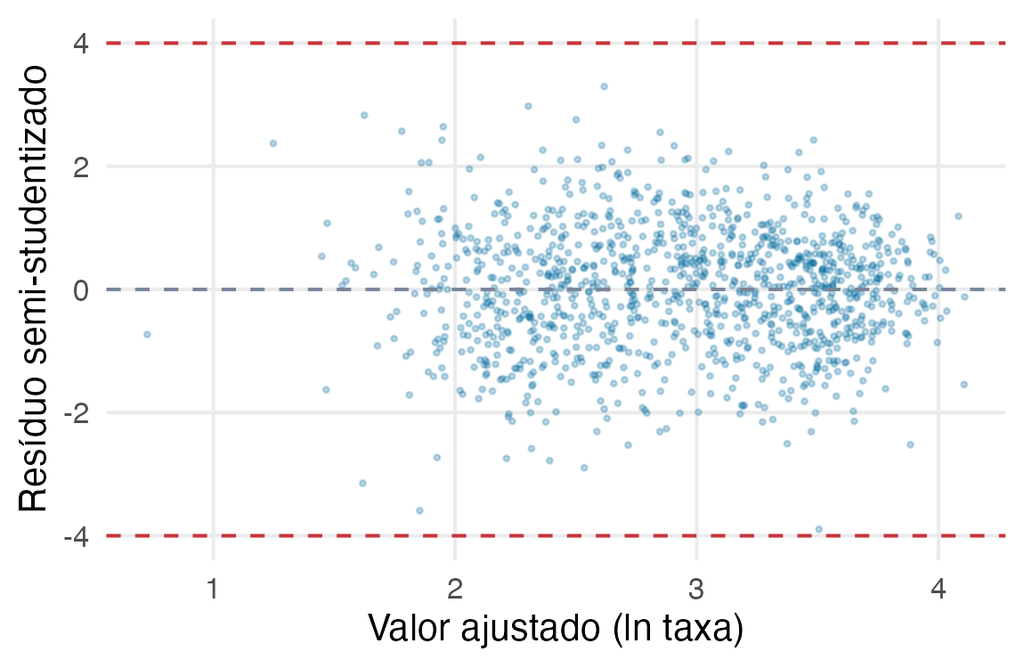

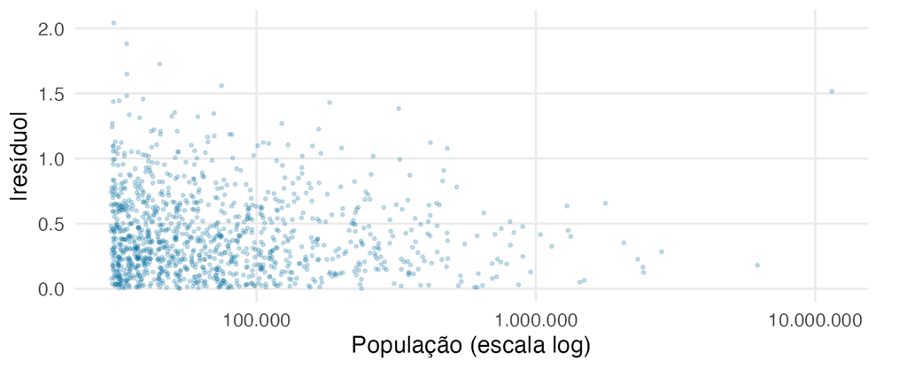

Buscamos resíduos próximos de zero, sem curvatura sistemática e com dispersão semelhante. A dispersão muda com o tamanho dos municípios. Breusch–Pagan rejeita variância constante. Os intervalos e testes clássicos permanecem exploratórios, sem correção dessa variância.

### Distribuição dos resíduos

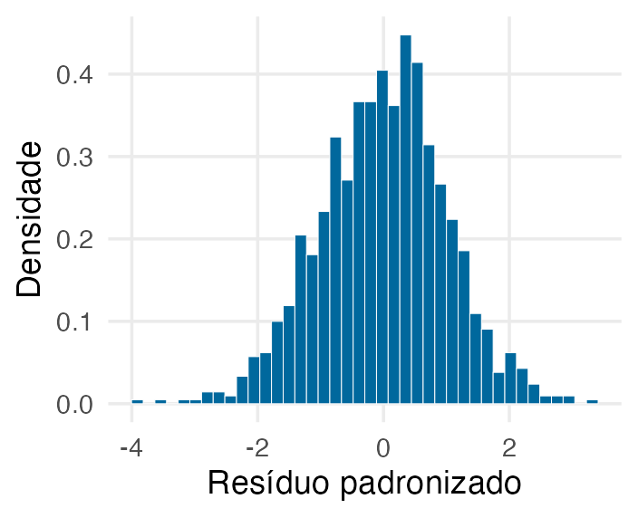

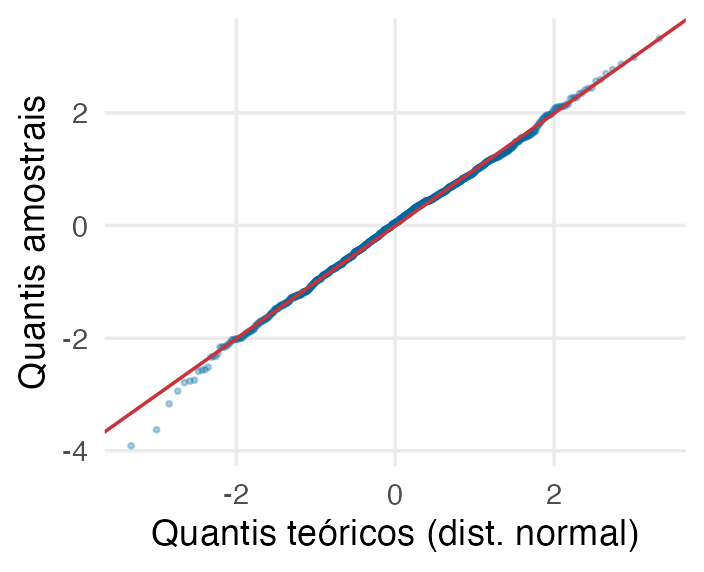

Os gráficos aproximam a distribuição normal. Shapiro–Wilk não rejeita normalidade, sem comprová-la. Esse resultado não resolve a variância desigual nem demonstra independência espacial.

### Box-Cox com a especificação final

O código anterior contém a transformação auxiliar inicial. Esta conferência repete o diagnóstico com os termos finais.

**Código**

```r
bc_final <- MASS::boxcox(lm(update(formula(modelo$final), y ~ .), data = modelo$d, y = TRUE, qr = TRUE),
                         lambda = seq(-.5, 1.2, .001), plotit = FALSE)
limite <- max(bc_final$y) - qchisq(.95, 1) / 2
potencia <- bc_final$x[which.max(bc_final$y)]
intervalo <- range(bc_final$x[bc_final$y > limite])
knitr::kable(data.frame(potencia = potencia, inferior = intervalo[1], superior = intervalo[2]))
```

| potencia | inferior | superior |
| --- | --- | --- |
| 0.174 | 0.117 | 0.232 |

**Código**

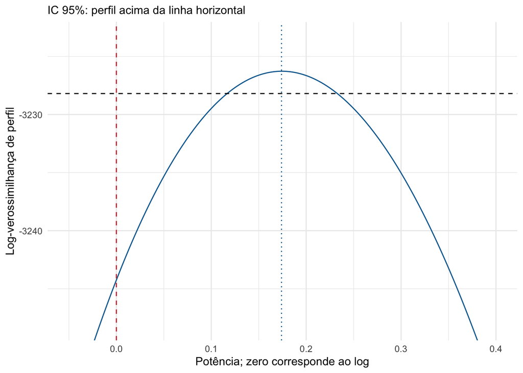

```r
ggplot(data.frame(lambda = bc_final$x, perfil = bc_final$y), aes(lambda, perfil)) +
  geom_line(colour = "#00689D") + geom_hline(yintercept = limite, linetype = 2) +
  geom_vline(xintercept = 0, colour = "#C8343B", linetype = 2) +
  geom_vline(xintercept = potencia, colour = "#00689D", linetype = 3) +
  coord_cartesian(xlim = c(-.05, .4), ylim = c(limite - 20, max(bc_final$y) + 3)) +
  labs(x = "Potência; zero corresponde ao log", y = "Log-verossimilhança de perfil",
       subtitle = "IC 95%: perfil acima da linha horizontal") + theme_minimal()
```

A potência zero, correspondente ao log, fica fora do intervalo. O diagnóstico não selecionou o log como potência ótima. Essa limitação deve acompanhar a interpretação, sem trocar o modelo apenas para obter testes favoráveis.

## Resultados e hipóteses

**Código**

```r
knitr::kable(modelo$efeitos[, c("variavel", "mudanca", "efeito_pct", "ic_inf_pct", "ic_sup_pct", "p")], digits = 4)
```

| variavel | mudanca | efeito_pct | ic_inf_pct | ic_sup_pct | p |
| --- | --- | --- | --- | --- | --- |
| % urbana | +10 pontos | 11.7959 | 8.2971 | 15.4077 | 0.0000 |
| Desocupação | +1 ponto | -1.8085 | -3.3263 | -0.2668 | 0.0217 |
| Frequência escolar 15–17 | +5 pontos | -8.6345 | -11.8605 | -5.2905 | 0.0000 |
| Distorção idade-série (EM) | +10 pontos | 15.5836 | 11.5378 | 19.7762 | 0.0000 |
| Migração recente | +5 pontos | 2.0520 | -0.6877 | 4.8672 | 0.1433 |

**Código**

```r
knitr::kable(modelo$gini, digits = 4)
```

| percentil | renda | efeito_pct | ic_inf_pct | ic_sup_pct | p |
| --- | --- | --- | --- | --- | --- |
| 10 | 699.150 | -10.0470 | -16.7788 | -2.7706 | 0.0077 |
| 25 | 872.960 | -2.3481 | -8.2908 | 3.9797 | 0.4579 |
| 50 | 1383.470 | 15.7836 | 10.5588 | 21.2553 | 0.0000 |
| 75 | 1739.540 | 26.0192 | 19.8495 | 32.5064 | 0.0000 |
| 90 | 2043.102 | 33.7441 | 26.2738 | 41.6563 | 0.0000 |

Os percentuais descrevem mudanças na taxa típica derivada do ajuste em log, mantendo as demais explicativas constantes. Eles não descrevem uma média aritmética prevista nem demonstram causa.

- A associação do Gini depende da renda. A hipótese de efeito positivo uniforme não descreve todo o resultado.
- Frequência escolar e atraso escolar apresentam direções compatíveis com a hipótese de exclusão escolar.
- Migração recente permanece no modelo, sem evidência clara de associação no ajuste final.
- O sinal negativo da desocupação é frágil; sua causa não foi identificada.

## Limites e próximos passos

A variância desigual, o possível sub-registro, o Gini aproximado e a independência espacial não verificada limitam a inferência. O recorte exclui municípios pequenos e não permite generalizar diretamente seus resultados a eles. O estudo descreve associações municipais, sem identificar causas ou riscos individuais. Trabalhos futuros podem tratar a variância, investigar dependência espacial e avaliar estabilidade em outros períodos.

## Ambiente da execução

**Código**